# Creating maps with ggplot2+sf

Mel Moreno

# Introduction

## Beautiful maps in a beautiful world

Maps are used in a variety of fields to express data in an appealing and interpretive image. Data can be expressed into simplified complex patterns, and this data interpretation is generally lost if the data is written out into spread sheets. Maps can add vital context by incorporating many variables into and easy to read and relatable context. Maps are also very important in the information world because they can quickly allow the public to gain better insight to make better personal decisions. It’s critical to have maps be effective, which means creating maps that can be understood by your target audience. Maps that need to be understood by children would very different from maps intended for geographers. Knowing what elements are required to enhance your data is key into making effective maps.

Some elements of a map that should be considered are polygon, points, lines, and text. With that in mind, we need to think about what in our map is required to really make an impact on our intended audience. Layout and formatting can also be used to enhance your data visually. It’s important to think about the arrangement of these maps elements and how they will be placed to make a maximum impact on the target audience. Polygons, in a map, are shapes in a map such as counties. Lines are shapes that are not filled with any aspect, such as highways, streams, or roads. Points on a map are used to specify small specific areas such as city locations.

Using R to create maps is very user friendly. You can add and remove elements on a map with ease. It is also easy to reproduce the same maps for different data sets. It is important to be able to script the elements of a map so that it can used and interpreted by any user. It’s relatively easy to e-mail R codes to colleagues, so the community aspect of R is very developed. Any code in R can be tweaked to make major enhancements with a stroke of a key.

Current solutions for creating maps are ArcGIS, QGIS, eSpatial, etc. The reason for using R is because it is a powerful and flexible tool. R can be used from calculating data sets to create graphs and maps with the same data set. R is also free, which makes it very easily accessible to anyone. Some other advantages of using R is that it has an interactive language, data structures, graphics availability, a developed community, repairing/replacing missing data, and the advantage of adding more tools through packages.

## A solution using R and its ecosystem of packages

R is a free and open-source software development environment (IDE) that is used for computing statistical data and graphic in a programmable language. R requires different packages installed to allow for linear and nonlinear modelling, statistical tests, time series analysis, classification, clustering, etc. CRAN, the comprehensive R archive network, which consists of a network of ftp and web servers that store identical versions of code and documentation for R. R is a scriptable language that allows the user to write out a code in which it will execute the command specified.

Packages in R create an ecosystem of different data analysis and interpretation. There are packages that are already programmed into a newly installed R, and we will be using several of those packages, as well as some developing packages.

The package `ggplot2` implements the grammar of graphics in R, as a way to create code that make sense to the user: The grammar of graphics is a term used to breaks up graphs into semantic components, such as geometries and layers. Practically speaking, it allows (and forces!) the user to focus on graph elements at a higher level of abstraction, and how the data must be structured to achieve the expected outcome.

While `ggplot2` is becoming the *de facto* standard for R graphs, it does not handle spatial data specifically. The current standard for spatial objects in R is defined as `Spatial` classes in the package `sp`, but a new standard following the “simple feature” standard is currently in development in the package `sf`. The development version of the package `ggplot2` now allows the programmer to create layers using simple features from the package `sf`. The combination of `ggplot2` and `sf` therefore enable to create maps, using the grammar of graphics, just as informative or visually appealing as any GIS software.

## Preparation of R

To download R, you can vist the CRAN website https://www.r-project.org/. You can choose to download R for PC users or Mac. R is a highly recommended program because it is a free open-source software that is constantly updating nd upgrading.

Packages can be installed with the following code:

```r
install.packages()
```

Some packages, such as `legendMap` and 1ggplot2`, are currently only available on GitHub, so we use the package`devtools` to install them:

```r
install.packages(c("devtools", "ggplot2", "ggthemes",
    "maps", "maptools", "rgdal", "rgeos", "rworldmap", "rworldxtra",
    "sf", "sp", "tidyverse", "tools"))

library(devtools)

devtools::install_github("tidyverse/ggplot2")
devtools::install_github("3wen/legendMap")
```

We start by loading the necessary packages for all maps:

```r
library(ggplot2)
library(sf)
library(sp)
```

# General concepts illustrated with the World Map

## Data and basic plot (`ggplot` and `geom_sf`)

First let’s start with creating a base map of the world using `rworldmap`. This base map will then be extended with different geographic or graph elements, as well as zoomed in to an area of interest.

The package `rworldmap` provides a map of countries of the entire world; a map with higher resolution is available in the package `rworldxtra`. We use the function `getMap` to extract the world map (the resolution can be set to `"low"`, if preferred):

```r
library(rworldmap)
library(rworldxtra)

world <- getMap(resolution = "high")
class(world)
```

The world map is available as a `SpatialPolygonsDataFrame`; we thus convert it to a simple feature using `st_as_sf` (from package `sf`):

```r
world <- st_as_sf(world)
class(world)
```

We can check that the map was properly retrieved and converted into an `sf` object, and plot it:

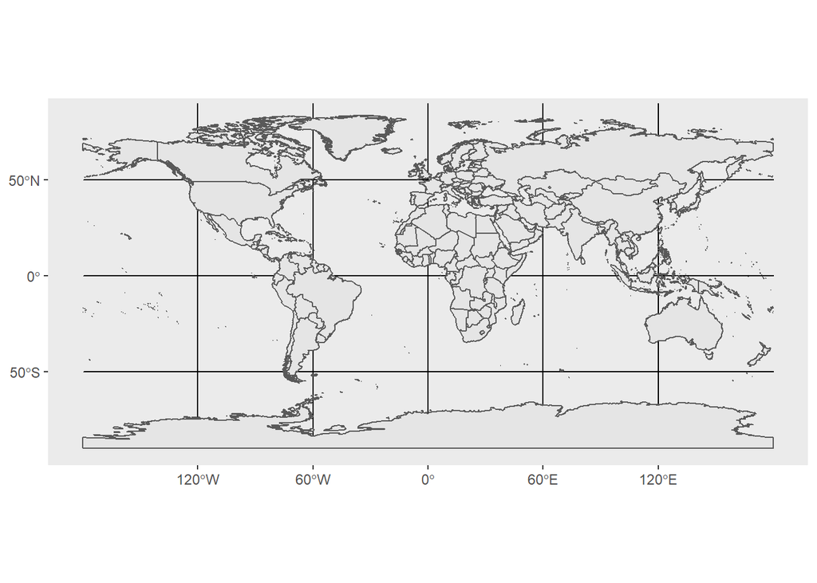

```r
ggplot(data = world) +
    geom_sf()
```

This call nicely introduces the structure of a `ggplot` call: The first part `ggplot(data = world)` initiates the `ggplot` graph, and indicates that the main data is stored in the `world` object. The line ends up with a `+` sign, which indicate that the call is not complete yet, and each subsequent line correspond to another layer or scale. In this case, we use the `geom_sf` function, which simply add a geometry stored in a `sf` object. By default, all geometry functions use the main data set up in `ggplot()`, but we will see later how to provide additional data.

Note that layers are added one at a time in a `ggplot` call, so the order of each layer is very important. All data will have to be in an `sf` format to be used by `ggplot2`, and should be converted from `sp` to `sf` if necessary.

## Titles and Subtitles (`ggtitle`)

We can add a title and subtitle to our map using the command `ggtitle`. Make sure you add the quotation marks around your title and subtitle names:

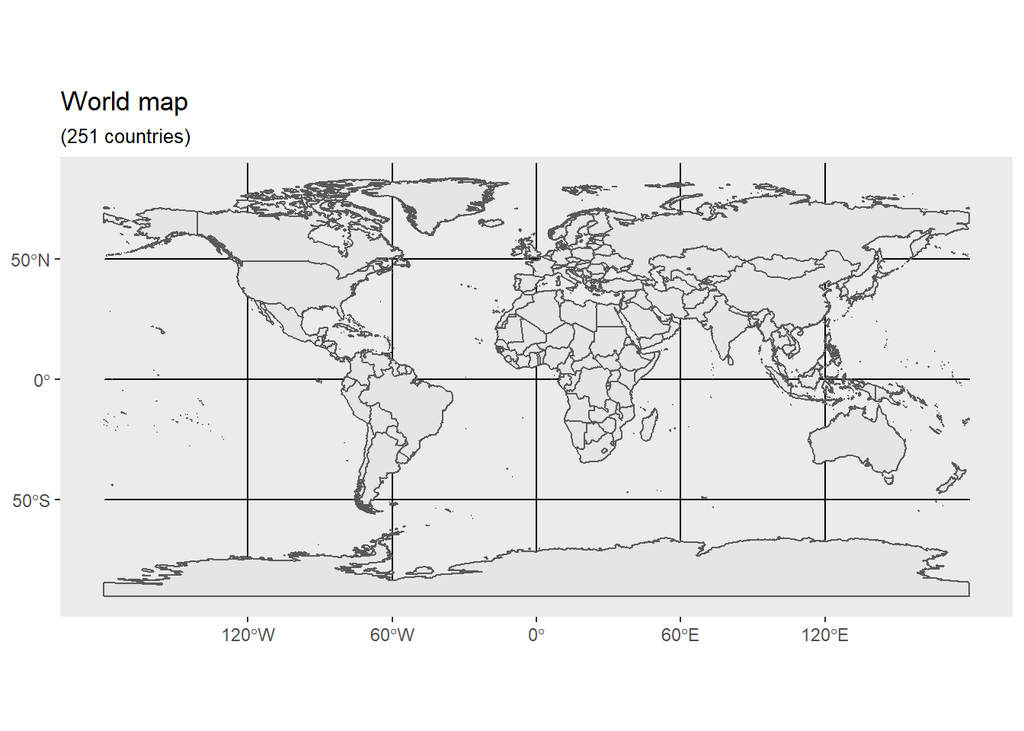

```r
ggplot(data = world) +
    geom_sf() +
    ggtitle("World map", subtitle = paste0("(", length(unique(world$NAME)), " countries)"))
```

## Axis Titles (`xlab`/`ylab`)

We can change the axis names to something more suitable. Depending on what your map displays, axis labels could be different.

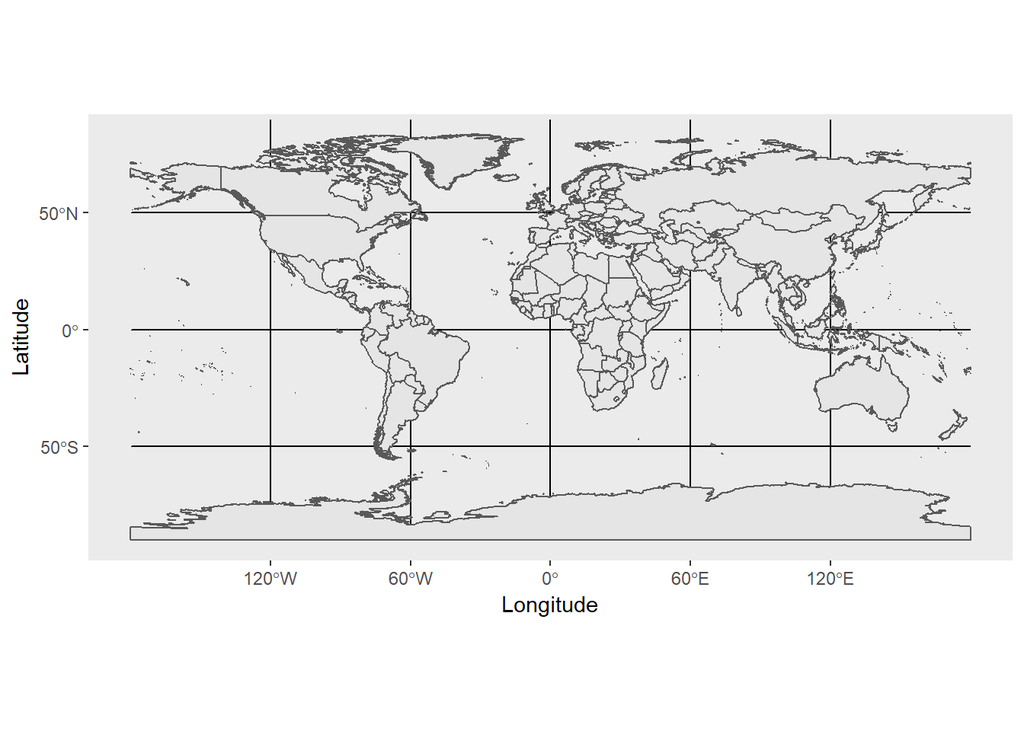

```r
ggplot(data = world) +
    geom_sf() +
    xlab("Longitude") + ylab("Latitude")
```

## Map Color (`geom_sf`)

In this example, we will be filling the polygons of the countries with a green color (argument `fill`), and using black for the outline of the countries (argument `color`):

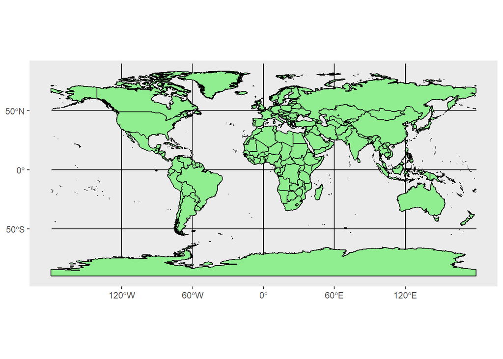

```r
ggplot(data = world) +
    geom_sf(color = "black", fill = "lightgreen")
```

`ggplot2` allows the use of more complex color schemes, such as a gradient on one variable of the data. Let us see how to use the population of each country (variable `POP_EST` of the `world` object) here:

```r
ggplot(data = world) +
    geom_sf(aes(fill=POP_EST))
```

[output not shown]

## Zoom in (`coord_sf`)

We can set the coordinates of the map to “zoom” in the area we are interested in mapping. To do this, we use `coord_sf` to create our coordinate settings, with limits on the x-axis (`xlim`), and on the y-axis (`ylim`). Note that the limits are automatically expanded by a fraction, so that selected data and axes don’t overlap. It is possible to set the zoom to the exact limits provided with `expand = FALSE`).

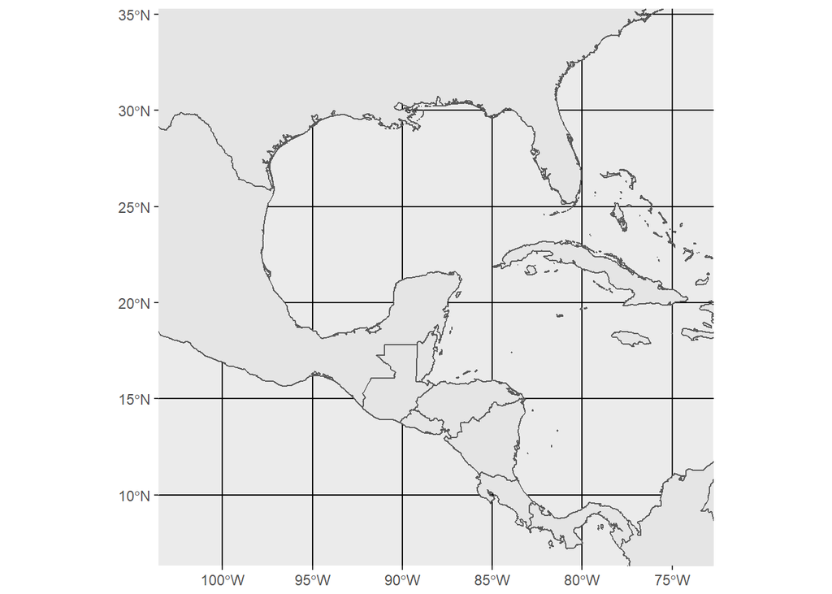

```r
ggplot(data = world) +
    geom_sf() +
    coord_sf(xlim = c(-102.15, -74.12), ylim = c(7.65, 33.97))
```

## Scale Bar and North Arrow

Many packages are available to create a scale bar on a map (e.g. `prettymapr` or `vcd`“). The package `legendMap` provides an easy-to-use function that allows to add simultaneously the north symbol and a scale bar into the `ggplot` map:

```r
library(legendMap)
```

Five arguments need to be set manually: `lon`, `lat`, `distance_lon`, `distance_lat`, and `distance_legend`. The argument `distance_lon` is the length of each rectangle. The argument `distance_lat` is the width of each rectangle.

The location of the scale bar has to be specified in longitude/latitude in the `lon` and `lat` arguments. The shaded distance inside the scale bar is controlled by the `distance_lon` argument. In our case, 500 km is a good distance to use.

Additionally, it is possible to change the font size for the legend of the scale bar (argument `legend_size`, which defaults to 3). The North arrow behind the “N” north symbol can also be adjusted for its length (`arrow_length`), its distance to the scale (`arrow_distance`), or the size the N north symbol itself (`arrow_north_size`, which defaults to 6).

Note that all distances (`distance_lon`, `distance_lat`, `distance_legend`, `arrow_length`, `arrow_distance`) are set to `"km"` by default in `distance_unit`; they can also be set to nautical miles with “nm”, or miles with “mi”.

More information on this package can be found here. https://github.com/3wen/legendMap/blob/master/R/legende_cartes.R

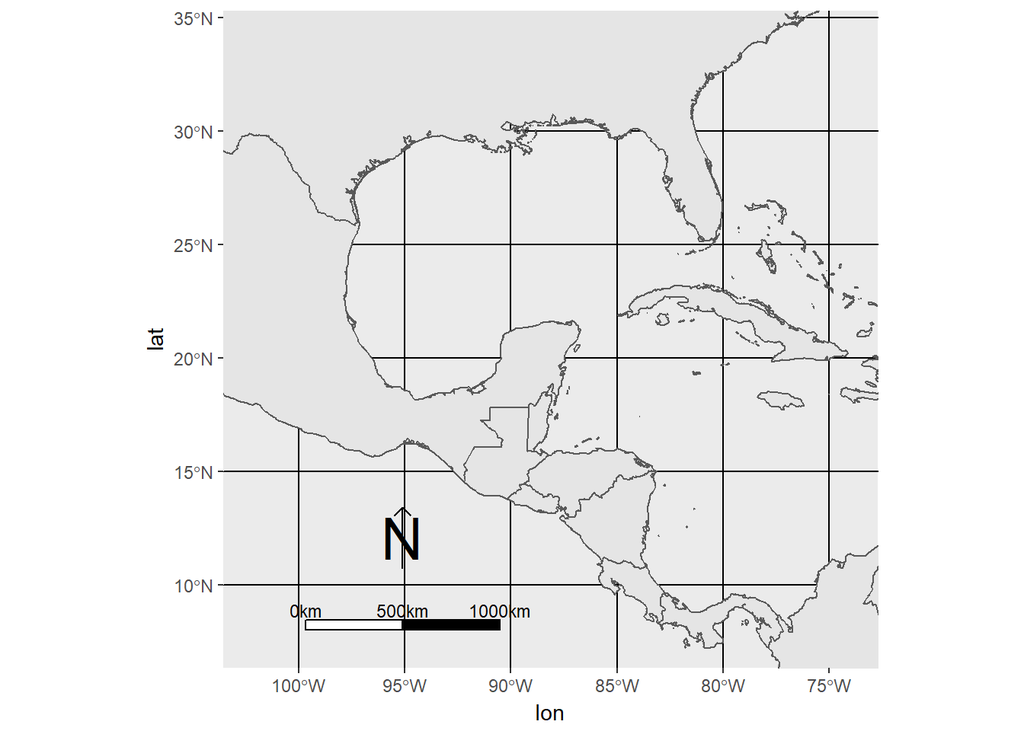

```r
ggplot(data = world) +
    geom_sf() +
    coord_sf(xlim = c(-102.15, -74.12), ylim = c(7.65, 33.97)) +
    scale_bar(lon = -99.66, lat = 8, distance_lon = 500,
        distance_lat = 50, distance_legend = 100, arrow_length = 300,
        arrow_north_size = 10)
```

## Country Names

The `world` data set already contains country names and the coordinates of the centroid of each country (among more information). We can use this information to plot country names, using `world` as a regular `data.frame` in `ggplot2`. We first check the country name information:

```r
head(world[, c("NAME", "LON", "LAT")])
```

[output not shown]

The command `geom_text` can be used to add a layer of text to a graphic. The command `geom_text` requires the data needed to enter the country names, which is the same data as the world map. We can adjust the size (argument `size`). By default, the text is centered on the coordinates provided; we can adjust the alignment horizontally or vertically using the arguments `hjust` and `vjust`, which can either be a number between 0 (right/bottom) and 1 (top/left) or a character (“left”, “middle”, “right”, “bottom”, “center”, “top”), or we can offset the text horizontally or vertically with the argument `nudge_x` and `nudge_y`.

We can also adjust the font of the text, for instance its color (argument `colour`) or the type of font (`fontface`, which was set to `"bold"`). Finally, the argument `check_overlap` remove country names that are overlapping each other.

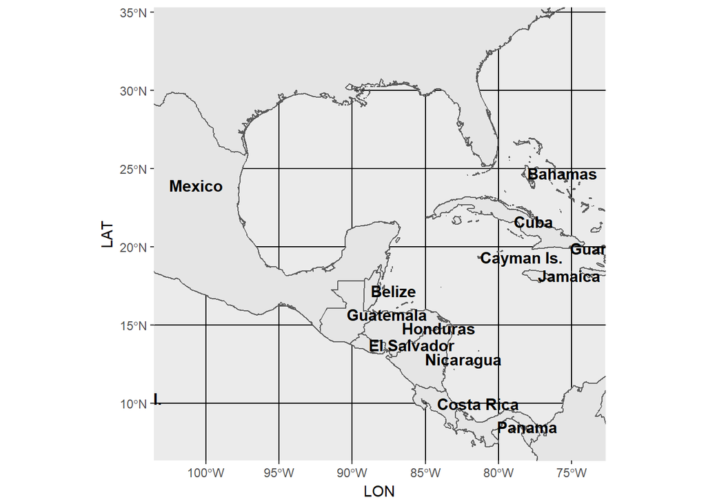

```r
ggplot(data = world) +
    geom_sf() +
    coord_sf(xlim = c(-102.15, -74.12), ylim = c(7.65, 33.97)) +
    geom_text(aes(LON, LAT, label = NAME), size = 4, hjust = "left",
        colour = "black", fontface = "bold", check_overlap = TRUE)
```

## Themes and Final Map

Now to make the final touches. We want to edit the theme of the map to make it more appealing. We added `theme_classic` for a standard theme, but there are many other themes that can be selected from. You can experiment adding and removing themes to see which one best suits your map. The argument `legend.position`, wasn’t use since we don’t require a legend in our map. Otherwise, such variables such as `topright` or `bottomleft` might be used. The `panel.grid.major` will allow us to edit the grid lines in the map. We chose a gray color, with a line type of dashed to break up the map borders from the grid lines. We wanted to add some color to the map backgraound, which is the ocean essentially, so we changed that with `panel.background`. We really wanted a border around the map, so the `panel.border` argument was used to add one. It will take some time to see elements of the theme need to be changed or added to best meet your map needs. There are many more aesthetics can be added to your custom theme, and they are all listed in the ggplot2 pdf in Helpful Resources.

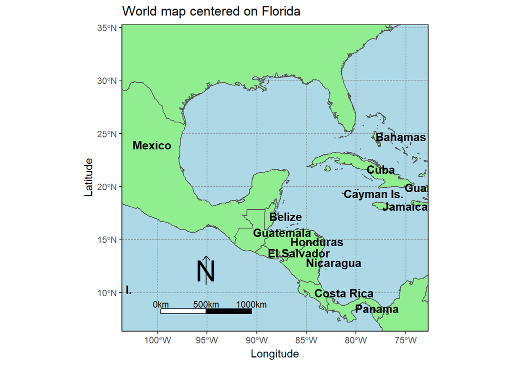

```r
ggplot(data = world) +
    geom_sf(fill = "lightgreen") +
    coord_sf(xlim = c(-102.15, -74.12), ylim = c(7.65, 33.97)) +
    ggtitle ("World map centered on Florida") +
    scale_bar(lon = -99.66, lat = 8, distance_lon = 500,
        distance_lat = 50, distance_legend = 100, arrow_length = 300,
        arrow_north_size = 10) +
    xlab("Longitude") + ylab("Latitude") +
    geom_text(aes(LON, LAT, label = NAME), size = 4, hjust = "left",
        colour = "black", fontface = "bold", check_overlap = TRUE) +
    theme_classic() +
    theme(panel.grid.major = element_line(colour = gray(.5),
        linetype = "dashed", size = 0.5),
        panel.background = element_rect(fill = "lightblue"),
        panel.border = element_rect(fill = NA))
```

# Additional layers

## Introduction

In the previous section, we presented general concepts with a map with little information (country borders). The modular approach of `ggplot2` allows to add additional layers in subsequent additions of `geom_sf`, for instance water bodies or terrain features, as will be illustrated in this section.

## Point coordinates (`geom_point`)

We start by defining two study sites, according to their longitude and latitude. The information is stored in a `data.frame`, with two variables `longitude` and `latitude`:

```r
(sites <- data.frame(longitude = c(-80.144, -80.109), latitude = c(26.479, 26.830)))
```

The easiest way to add point coordinates is with the general-purpose function `geom_point`, which works on any X/Y coordinates, of regular data points (i.e. not geographic). As such, we can adjust all characteristics of points (e.g. color of the outline and the filling, shape, size, etc.), for all points, or using grouping from the data (i.e defining their “aesthetics”). In this example, we add the two points as diamonds (`shape = 23`), filled in dark red (`fill = "darkred"`) and of bigger size (`size = 4`):

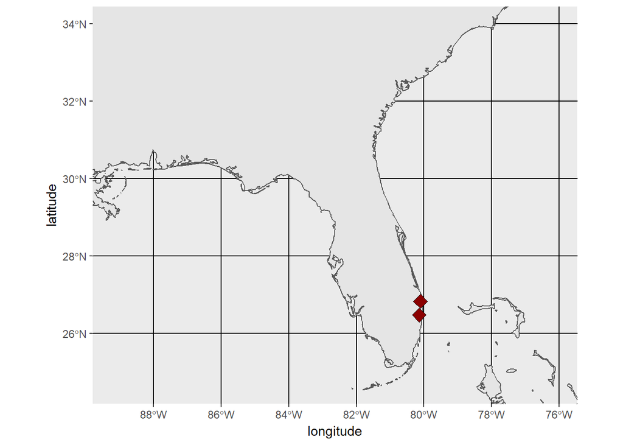

```r
ggplot(data = world) +
  geom_sf() +
  coord_sf(xlim = c(-89.15, -76.12), ylim = c(24.65, 33.97)) +
  geom_point(data = sites, aes(x = longitude, y = latitude), size = 4, shape = 23, fill = "darkred")
```

Many layers can be added using `geom_sf`. Many times, if a layer doesn’t display correctly, it might have to be converted as an `sf` object. The coordinates of `sites` can also be implemented to the map with `geom_sf`.

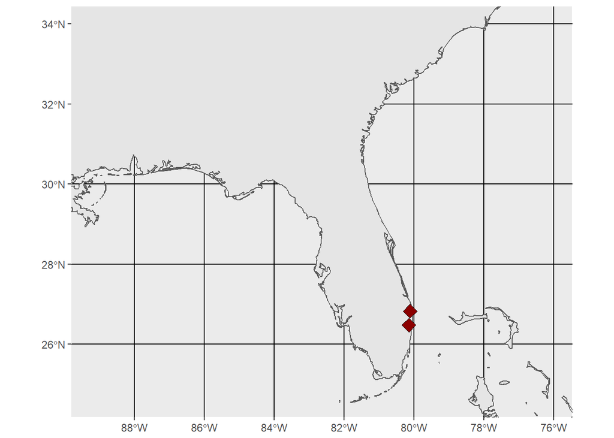

```r
sites_sf <- st_as_sf(sites, coords = c("longitude", "latitude"), crs = 4326)

ggplot(data = world) +
  geom_sf() +
  geom_sf(data = sites_sf, size = 4, shape = 23, fill = "darkred") +
  coord_sf(xlim = c(-89.15, -76.12), ylim = c(24.65, 33.97))
```

## State and County map/name data

In this example, we will add US state borders and names for detail. Entering the correct x and y-axis names will ensure our state borders will display properly. Double check the heading labels prior to plotting.

```r
states <- map_data("state")
state_sf <- st_as_sf(states, coords = c("long", "lat"), crs = 4326)
head(states)
```

[output not shown]

We can retrieve the state names with the same map data we just collected. In our case, we would like the state names to be in the middle of each state polygon. We will use an aggregate command to do this. We combine the longitude and latitude, with the state region in the data set. We will set the function to use the mean and range to place the state names in the middle of the state.

```r
cnames <- aggregate(cbind(long, lat) ~ region, data=states,
          FUN=function(x)mean(range(x)))
```

We noticed that these state names were not capitalized, so we will go ahead and make that adjustment. The names can be capitalized using the package `tools`.

```r
library(tools)
cnames$region <- toTitleCase(cnames$region)
stringr::str_to_title("Me and my girl friend")
```

We would like even more detail for the map, so we will add county lines. Depending on what you want to display on your map, you might not want to display county outlines. Once again we will check the headings of the county lines to make sure they are the same headings as the state borders.

```r
counties <- map_data("county")
county_sf <- st_as_sf(counties, coords = c("long", "lat"), crs = 4326)
head(county_sf)
```

## Plotting County Lines

Now that we have the area we are interested in, we can add the county lines we retrieved earlier. The county lines can be modified for different line widths and colors. In this case we used dark green to make the county lines different from the state borders. We use the code `geom_polygon` to add the polygon lines of the county borders. We previously tried with `geom_lines`, but it was not succesful in creating the county outlines accurately. Once again, the command requires the data for the layer. You can then choose the fill color for the inside of the polygon, and the color of the actual lines of the counties. It can be useful to fill in the counties with varying color, if you think it will add more aethetics to your map. Now the aes() argument reqiures the x and y coordinates of the counties layer. We are also inheriting the previous code aethetics into this layer with inherit.aes=.

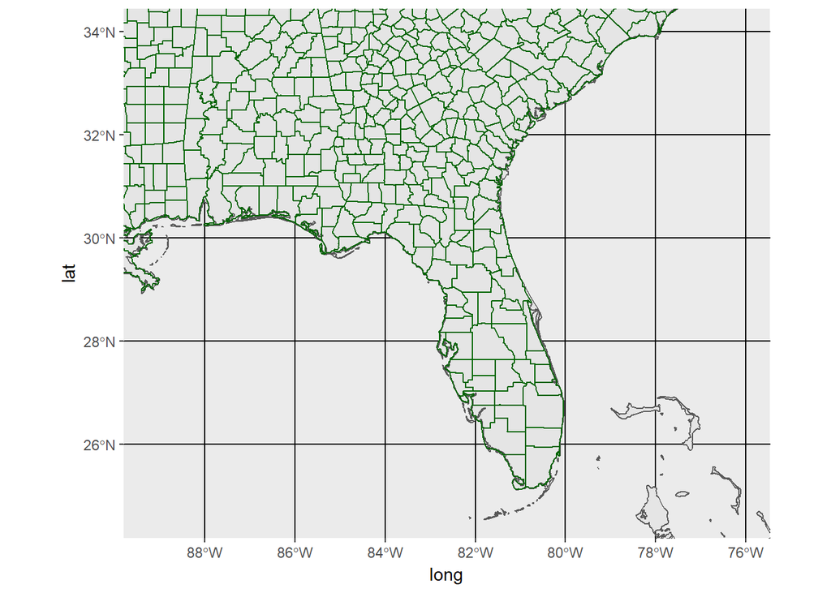

```r
ggplot() +
  geom_sf(data=world) +
  coord_sf(xlim = c(-89.15, -76.12), ylim = c(24.65, 33.97), expand=TRUE ) +
  geom_polygon(data=counties, fill= NA, colour= "darkgreen", aes(x=long, y=lat, group=group),inherit.aes=TRUE)
```

## Plotting State Borders/Names

To continue adding to our map, we will be adding the state borders. We are using the same `geom_polygon` command, and the arguments used are the same as for county lines. The difference would be to make the color of the outline black, to really stand out, and to make the size thickness of the line slightly thicker than the county lines. We did not need to add a legend with aspects of the states, so we do not have arguments such as `color` or `fill` to draw the variables form.

For text on our map, we will be using `geom_text`. This function allows us to add any text we desire on our map. It can be used in various ways that will be show on other maps as well. Our `long` and `lat` is specified in the data, and we use region as our state labels. We then specified the size, is we wanted to inherit the previous aesthetics, the color, if wanted the program to check for overlapping names, if we wanted our text bold, and how we looked like the names to be nudged.

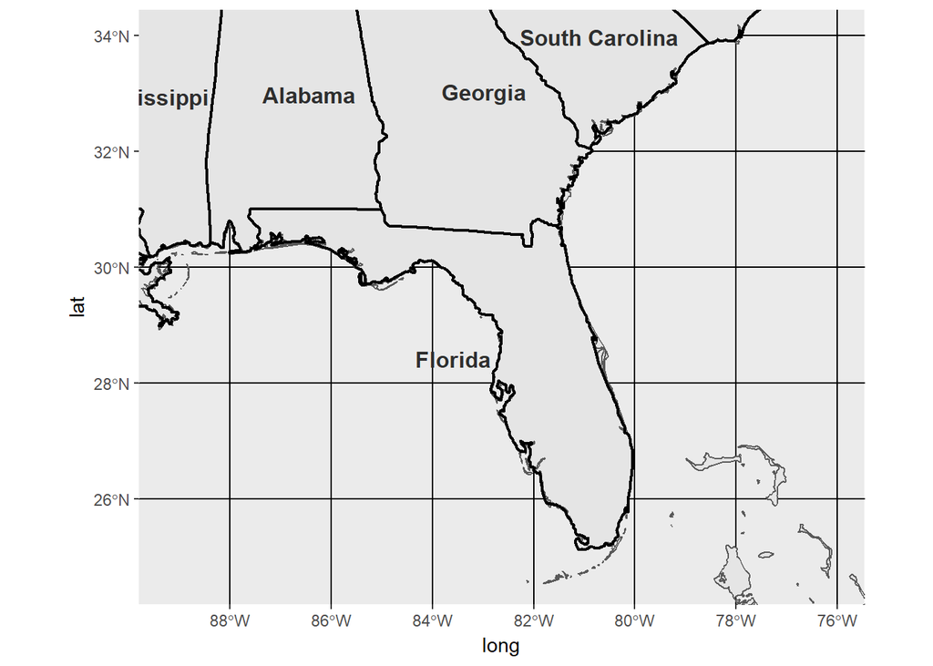

```r
ggplot() +
  geom_sf(data=world) +
  coord_sf(xlim = c(-89.15, -76.12), ylim = c(24.65, 33.97), expand=TRUE) +
  geom_polygon(data=states, fill= NA, colour= "black", aes(x=long, y=lat, group=group),inherit.aes=TRUE, size=.76) +
  geom_text(aes(long, lat, label = region), data = cnames, size = 4.2, inherit.aes = TRUE, col = "grey18", check_overlap = TRUE, fontface="bold", nudge_x=.25, nudge_y=.35)
```

## Themes and Final Map

Because our code is the same for title and subtitles, scale bar and north symbol, and axis titles we will not repeat the steps for this map. Please refer to those topics if you are unsure how to create/edit those features. For this map we will remove the axis titles since we will not be using coordinate units.

Now to make the final touches. We want to edit the theme of the map to make it more appealing. We added `theme_map`, for a standard theme, but there are many other themes that can be selected from. This theme removes the longitude and latitude lines around the map border. Please refure back to the World Map Themes and Final Map for a description of each argument.

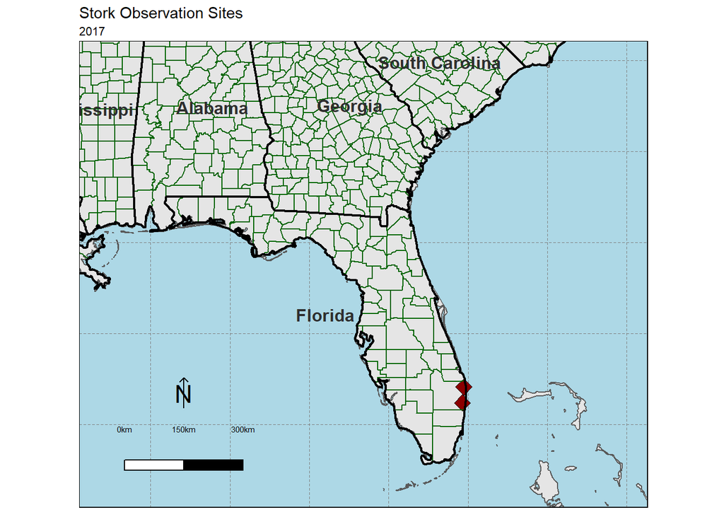

```r
library(ggthemes)

ggplot() +
  geom_sf(data=world) +
  geom_sf(data = sites_sf, size = 4, shape = 23, fill = "darkred") +
  coord_sf(xlim = c(-89.15, -76.12), ylim = c(24.65, 33.97), expand=TRUE ) +
  geom_polygon(data=counties, fill= NA, colour= "darkgreen", aes(x=long, y=lat, group=group),inherit.aes=TRUE) +
  geom_polygon(data=states, fill= NA, colour= "black", aes(x=long, y=lat, group=group),inherit.aes=TRUE, size=.76) +
  geom_text(aes(long, lat, label = region), data = cnames, size = 4.2, inherit.aes = TRUE, col = "grey18", check_overlap = TRUE, fontface="bold", nudge_x=.25, nudge_y=.35) +
  ggtitle ("Stork Observation Sites", subtitle = "2017") +
  scale_bar(lon = -88.66, lat =25,distance_lon = 150, distance_lat = 25, distance_legend = 100, dist_unit = "km",             arrow_length=75, arrow_distance=150, arrow_north_size =6, orientation= TRUE,legend_size=2) +
  theme_map() +
  theme(legend.position = "none", panel.grid.major = element_line(colour = gray(.5), linetype = "dashed", size = 0.5),        panel.background = element_rect(fill = "lightblue"), panel.border=element_rect(fill=NA))
```

## Final Notes

You should realize by now that adding layers on `ggplot` is relatively easy, as long as your data is configured correctly, and your arguments are valid. Depending on what you need for your own maps, you might need or not need some of those commands. You can create more than two points on any given map simply by adding another variable with coordinates.

## Saving with ggsave

```r
 ggsave("Floridamap.png", plot = last_plot(), device = "png", path = NULL,
         scale = 1, width = 7, height = 7,
         dpi = 300)
```

# Helpful Resources

## PDFs for packages

-ggplot2 https://cran.r-project.org/web/packages/ggplot2/ggplot2.pdf http://ggplot2.tidyverse.org/reference/stat_ecdf.html

-sf https://cran.r-project.org/web/packages/sf/sf.pdf

-sp https://cran.r-project.org/web/packages/sp/sp.pdf

-CRAN https://cran.r-project.org/

## Links and various tutorials

-Global Choropleth, world interactive, rotating map

http://ellisp.github.io/blog/2017/06/04/military-gdp

-Ggplotly

http://www.alexejgossmann.com/salaries_by_school_plotly_viz/

-R studio colors

http://www.stat.columbia.edu/~tzheng/files/Rcolor.pdf

-Plotting side by side

https://ikashnitsky.github.io/2017/align-six-maps/

-Leaflet

https://cengel.github.io/rspatial/4_Mapping.nb.html

Points with gganimate http://blog.cultureofinsight.com/2017/06/building-dot-density-maps-with-uk-census-data-in-r/

-Symobls and Points http://www.sthda.com/english/wiki/r-plot-pch-symbols-the-different-point-shapes-available-in-r

-Themes http://ggplot2.tidyverse.org/reference/theme.html

-Two graphs with same legend

https://github.com/tidyverse/ggplot2/wiki/share-a-legend-between-two-ggplot2-graphs